# The Assisgnment one

Tie Ma

2024-02-28

#Tie Ma #student number: 101316917 #ECON 5027 #Assignment one

Q2-D

```r
set.seed(10086)
#loding the data
Q2D_matrix <- matrix(c(
  0.23, -0.39, -0.03, 0.29, 0.33, -0.37, -0.32, -0.04, -0.51, -0.96,  # Yi
  1, 0, 1, 0, 0, 1, 0, 0, 1, 1,                                       # Xi1
  1, 2, 1, 1, 2, 2, 3, 3, 2, 3                                        # Xi2
),
nrow=10,
ncol=3,
byrow=FALSE )

#add one for the intercept
x <- cbind(1, Q2D_matrix[, 2:3])
y <- Q2D_matrix[, 1]

#time for the beta_hat
beta_hat <- solve(t(x) %*% x) %*% (t(x) %*% y)
e <- rnorm(6, mean = 0, sd = 1)

#constructed the model
Q2D_model <- function(x1, x2, beta_hat) {
  beta_hat[1] + beta_hat[2] * x1 + beta_hat[3] * x2 + e
}

#lode the data
Xi1_values <- c(0, 1)
Xi2_values <- c(1, 2, 3)

#The data frame
Q2D_data_frame <- expand.grid(Xi1 = Xi1_values, Xi2 = Xi2_values)

# Calculate the conditional expectations everything
conditional_expectations <- c(
  beta_hat[1] + beta_hat[2] * 0 + beta_hat[3] * 1,
  beta_hat[1] + beta_hat[2] * 0 + beta_hat[3] * 2,
  beta_hat[1] + beta_hat[2] * 0 + beta_hat[3] * 3,
  beta_hat[1] + beta_hat[2] * 1 + beta_hat[3] * 1,
  beta_hat[1] + beta_hat[2] * 1 + beta_hat[3] * 2,
  beta_hat[1] + beta_hat[2] * 1 + beta_hat[3] * 3
)

#final output matrix
conditional_matrix <- cbind(
  "E[Yi|Xi1=x1,Xi2=x2]" = conditional_expectations,
  Xi1 = c(0, 0, 0, 1, 1, 1),
  Xi2 = c(1, 2, 3, 1, 2, 3)
)

# print time
print(conditional_matrix)
```

```
##      E[Yi|Xi1=x1,Xi2=x2] Xi1 Xi2
## [1,]          0.42657143   0   1
## [2,]          0.04942857   0   2
## [3,]         -0.32771429   0   3
## [4,]         -0.02628571   1   1
## [5,]         -0.40342857   1   2
## [6,]         -0.78057143   1   3
```

Q2-E

```r
#calculate form Q2-a
#E[Yi|Xi1=0,Xi2=1]
E01 <- 0.29

#E[Yi|Xi1=0,Xi2=2]
E02 <- (-0.39+0.33)/2

#E[Yi|Xi1=0,Xi2=3]
E03 <- (-0.32-0.04)/2

#E[Yi|Xi1=0,Xi2=1]
E11 <-(0.23 - 0.03)/2

#E[Yi|Xi1=1,Xi2=2]
E12 <- (-0.37 -0.51)/2

#E[Yi|Xi1=1,Xi2=3]
E13 <- -0.96

QA_answer <-c(E01, E02, E03, E11, E12, E13)
#The comparsing Matrix

comparsing_matrix <- cbind(
  "E[Yi|Xi1=x1,Xi2=x2]_QD" = conditional_expectations,
  "E[Yi|Xi1=x1,Xi2=x2]_QA" = QA_answer,
  "difference" = conditional_expectations/QA_answer,
  Xi1 = c(0, 0, 0, 1, 1, 1),
  Xi2 = c(1, 2, 3, 1, 2, 3)
)

print(comparsing_matrix )
```

```
##      E[Yi|Xi1=x1,Xi2=x2]_QD E[Yi|Xi1=x1,Xi2=x2]_QA difference Xi1 Xi2
## [1,]             0.42657143                   0.29  1.4709360   0   1
## [2,]             0.04942857                  -0.03 -1.6476190   0   2
## [3,]            -0.32771429                  -0.18  1.8206349   0   3
## [4,]            -0.02628571                   0.10 -0.2628571   1   1
## [5,]            -0.40342857                  -0.44  0.9168831   1   2
## [6,]            -0.78057143                  -0.96  0.8130952   1   3
```

Q3-A

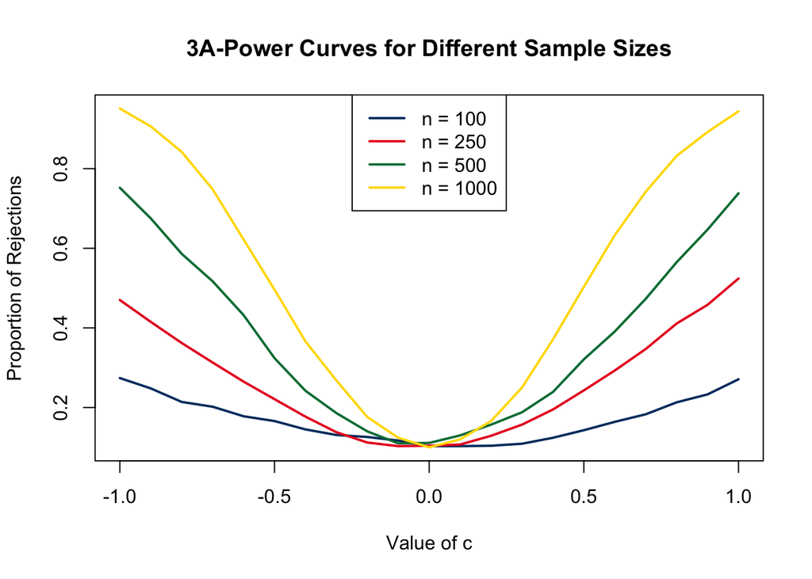

```r
#Q3-A##h0 = beta_2 = c versu h1 beta_2 not equal to c#
#clean the environment for the the assignment.
rm(list = ls())
set.seed(101310927)
#set the variance matrix
evil_variance_matrix <- matrix(c(1.0964, -0.5313, -0.5730,
                                 -0.5313, 0.9381, -0.4184,
                                 -0.5730, -0.4184, 1.0228), nrow = 3, ncol = 3, byrow = TRUE)

#set up the mu
mu <- c(1.1141, -0.6768, 3.3521)

# c sequence (from -1 to 1 by 0.1)
c_value <- seq(from = -1, to = 1, by = 0.1)

# Number of simulation rounds
R <- 1000

# Parameters
# the n is for the data generate process within the loop
# the n_value of for the loop to keep going.
n_value <- c(100, 250, 500, 1000)

#set up the beta_ture
beta_true <- c(-0.8, 0, 0, 0.1)

#the t-test with 0.05 degree of freedom (do not change to a you will lost it)
alpha <- 0.05



# The storage matrix
  #final_matrix
    Final_matrix <- matrix(0,ncol = length(c_value), nrow = length(n_value))

#the simulation time


for (i in 1:length(n_value)){
  #rest the n
  n <- n_value[i]
  #reset the TF matrix
  TF_matrix <- matrix(NA, ncol=length(c_value), nrow = R)

  #this loop run 1000 times with current value of n
  for (j in 1:R) {

    x <- mvrnorm(n, mu = mu, Sigma = evil_variance_matrix) # its should be "Sigma" not "sigma"

    # Add intercept (we now turn the x from 3x3 matrix to 3x4 matrix)
    x <- cbind(rep(1, n), x)
    # e need to be processed within the loop
    e <- rnorm(n, mean = 0, sd = 1)  #normal distribution
    #now its the time for the calculate the y!
    y <- x %*% beta_true + e

    # OLS estimation
    beta_hat <- solve(t(x) %*% x) %*% (t(x) %*% y)
    eps_hat <- y - x %*% beta_hat

    #the degree of freedom
    dof <- n - length(beta_hat)
    #残差 the mu
    sigma_hat_sq <- (1 / dof) * sum(eps_hat^2)
    #estimate of the
    v_beta_hat <- solve(t(x) %*% x) * sigma_hat_sq
    # standard error time!
    diag_v_beta_hat <- diag(v_beta_hat)
    sd <- sqrt(diag_v_beta_hat)

    #the T- test time!
    for (k in 1:length(c_value)) {
      #T statistic for the beta3
      t_st <- (beta_hat[3,] - c_value[k])/sd[3]
      #T test P value
      t_p_value <- 1 - pt(abs(t_st), dof) #using the TA's note!
   #the matrix time!
      #count the p_value
      TF_matrix[j, k] <- t_p_value < 0.05
      #this things was crashed my mac for times。
      #I spend 2 hours on this line a lone
     }
   }
  Final_matrix[i, ] <- colMeans(TF_matrix)
  #and other hour on this line.
 }

#god tis finally end, I rest in peace.


#change the row name of the matrix
rownames(Final_matrix) <- c("n = 100", "n = 250", "n = 500", "n = 1000")


# Assuming Final_matrix and c_value are already defined

# Colors
dw_blue <- "#003b6f"  # Doctor Who blue
cr_red <- "#e91c25"   # Carlton red
ua_green <- "#007c41"  # ualberta green
ua_gold <- "#ffdb05"  # ualberta gold

# Prepare the data
n_labels <- c("n = 100", "n = 250", "n = 500", "n = 1000")
colors <- c(dw_blue, cr_red, ua_green, ua_gold)

# Plotting
 plot(c_value, Final_matrix[1, ], type = "l", col = colors[1], ylim = c(min(Final_matrix), max(Final_matrix)), xlab = "Value of c", ylab = "Proportion of Rejections", main = "3A-Power Curves for Different Sample Sizes", lwd = 2, xlim = c(-1, 1))
lines(c_value, Final_matrix[2, ], col = colors[2], lwd = 2)
lines(c_value, Final_matrix[3, ], col = colors[3], lwd = 2)
lines(c_value, Final_matrix[4, ], col = colors[4], lwd = 2)
legend("top", legend = n_labels, col = colors, lty = 1, lwd = 2)
```

The power curves suggest that, when the number of n increase, the proportins of times of rejects has incrase for different value of C. compare n = 1000 with n= 100, we can see a sigignificent difference between proportion of rehjection. Howeer, the proportions rejected has never zero, the lowest proportions of regections is around 0.1. # As the sample size n increases, the power of the test increases, meaning that the proportion # of rejections of the null hypothesis goes up for values of c that are different from the true β2. # However, if c equals the true β2, the rejection rate should hover around the significance level α, # provided that the model is correctly specified and the assumptions of the OLS and t-test are satisfied.